# AMA_Assignment_2

```python
import pandas as pd
import numpy as np
import matplotlib.pyplot as plt
import seaborn as sns
from sklearn.preprocessing import StandardScaler
from sklearn.cluster import KMeans
from sklearn.metrics import silhouette_score
```

```python
# prompt: load a csv file

goku = pd.read_csv('/content/product_segmentation_dataset.csv')
# to view the first 5 rows of the dataframe
goku.head()
```

|  | Product Category | Price (USD) | Average Customer Rating | Units Sold | Stock Level | Discount Offered (%) | Product Warranty | Return Rate (%) |
| --- | --- | --- | --- | --- | --- | --- | --- | --- |
| 0 | Desk | 568.06 | 3.9 | 199 | 38 | 43.85 | Yes | 1.42 |
| 1 | Bed | 1332.68 | 4.4 | 185 | 41 | 47.20 | Yes | 6.26 |
| 2 | Cabinet | 1334.05 | 4.3 | 212 | 54 | 7.44 | Yes | 18.71 |
| 3 | Desk | 731.02 | 2.6 | 216 | 61 | 23.13 | Yes | 17.01 |
| 4 | Sofa | 752.33 | 3.7 | 205 | 104 | 49.05 | Yes | 19.64 |

```python
# Exploratory Data Analysis (EDA)

print("Dataset Overview:")
print(goku.head())
print("\nDataset Info:")
goku.info()
print("\nSummary Statistics:")
print(goku.describe())
```

```
Dataset Overview:
  Product Category  Price (USD)  Average Customer Rating  Units Sold  \
0             Desk       568.06                      3.9         199
1              Bed      1332.68                      4.4         185
2          Cabinet      1334.05                      4.3         212
3             Desk       731.02                      2.6         216
4             Sofa       752.33                      3.7         205

   Stock Level  Discount Offered (%) Product Warranty  Return Rate (%)
0           38                 43.85              Yes             1.42
1           41                 47.20              Yes             6.26
2           54                  7.44              Yes            18.71
3           61                 23.13              Yes            17.01
4          104                 49.05              Yes            19.64

Dataset Info:
<class 'pandas.core.frame.DataFrame'>
RangeIndex: 347 entries, 0 to 346
Data columns (total 8 columns):
 #   Column                   Non-Null Count  Dtype
---  ------                   --------------  -----
 0   Product Category         347 non-null    object
 1   Price (USD)              347 non-null    float64
 2   Average Customer Rating  347 non-null    float64
 3   Units Sold               347 non-null    int64
 4   Stock Level              347 non-null    int64
 5   Discount Offered (%)     347 non-null    float64
 6   Product Warranty         347 non-null    object
 7   Return Rate (%)          347 non-null    float64
dtypes: float64(4), int64(2), object(2)
memory usage: 21.8+ KB

Summary Statistics:
       Price (USD)  Average Customer Rating  Units Sold  Stock Level  \
count   347.000000               347.000000  347.000000   347.000000
mean   1144.086628                 3.063977  200.043228    50.020173
std     610.083179                 1.190472   14.002513    28.620744
min     126.780000                 1.000000  152.000000     0.000000
25%     596.475000                 2.000000  191.000000    30.000000
50%    1050.020000                 3.200000  200.000000    50.000000
75%    1823.570000                 4.100000  210.000000    69.500000
max    2000.000000                 5.000000  242.000000   131.000000

       Discount Offered (%)  Return Rate (%)
count            347.000000       347.000000
mean              25.087810        10.203112
std               14.858688         5.560203
min                0.010000         0.040000
25%               12.675000         5.875000
50%               24.830000        10.270000
75%               38.415000        14.900000
max               49.890000        19.930000
```

```python
# Check for missing values

print("\nMissing Values:")
print(goku.isnull().sum())
```

```
Missing Values:
Product Category           0
Price (USD)                0
Average Customer Rating    0
Units Sold                 0
Stock Level                0
Discount Offered (%)       0
Product Warranty           0
Return Rate (%)            0
dtype: int64
```

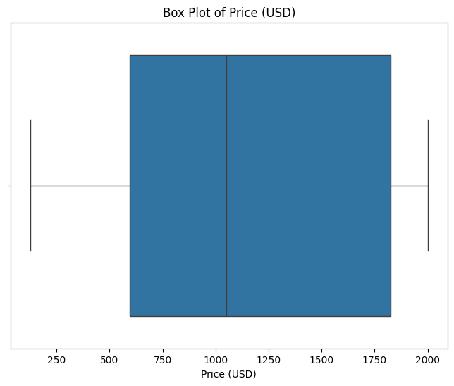

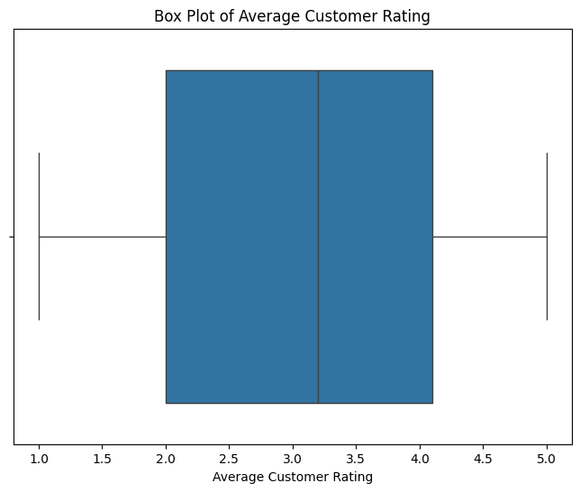

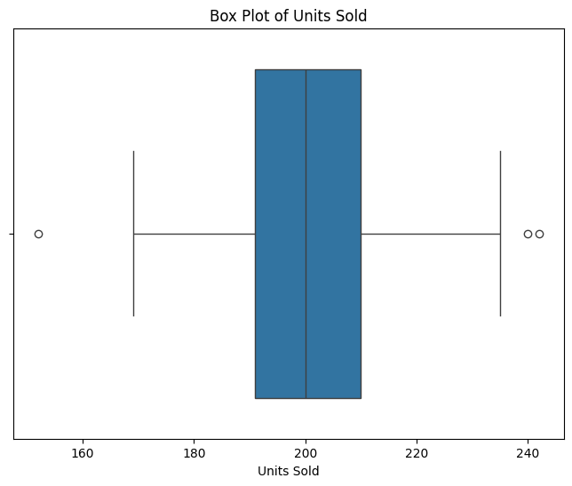

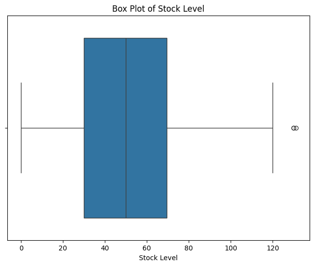

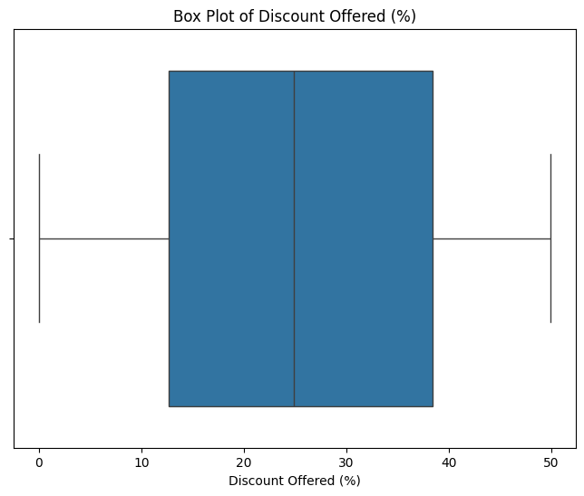

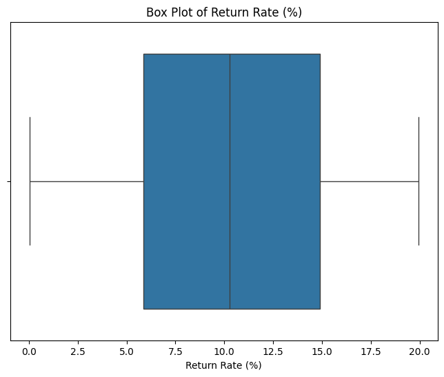

```python
# prompt: box plot for goku

# Box plot for each numerical feature
numerical_features = goku.select_dtypes(include=np.number).columns
for col in numerical_features:
    plt.figure(figsize=(8, 6))
    sns.boxplot(x=goku[col])
    plt.title(f"Box Plot of {col}")
    plt.show()
```

```python
# Scale numeric columns

scaler = StandardScaler()
numeric_columns = ['Price (USD)', 'Average Customer Rating', 'Units Sold', 'Stock Level', 'Discount Offered (%)', 'Return Rate (%)']  # Adjust based on actual columns
goku = scaler.fit_transform(goku[numeric_columns])
```

```python
# Convert the NumPy array back to a Pandas DataFrame
goku1 = pd.DataFrame(goku, columns=numeric_columns)
goku1.head() # Now this will work

# Alternatively, to display the first 5 rows of the NumPy array, use slicing:
print(goku1[:5])
```

```
   Price (USD)  Average Customer Rating  Units Sold  Stock Level  \
0    -0.945541                 0.703276   -0.074610    -0.420588
1     0.309574                 1.123884   -1.075875    -0.315617
2     0.311823                 1.039762    0.855135     0.139255
3    -0.678044                -0.390305    1.141210     0.384186
4    -0.643064                 0.535033    0.354503     1.888762

   Discount Offered (%)  Return Rate (%)
0              1.264532        -1.581920
1              1.490315        -0.710191
2             -1.189425         1.532169
3             -0.131952         1.225984
4              1.615001         1.699671
```

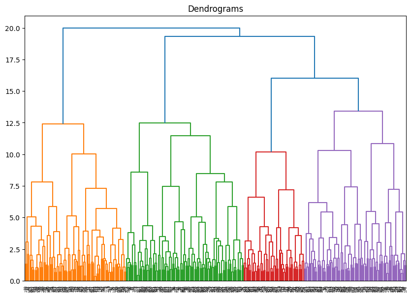

```python
# prompt: plot Dendrogram for goku1

import scipy.cluster.hierarchy as shc

plt.figure(figsize=(10, 7))
plt.title("Dendrograms")
dend = shc.dendrogram(shc.linkage(goku1, method='ward'))
```

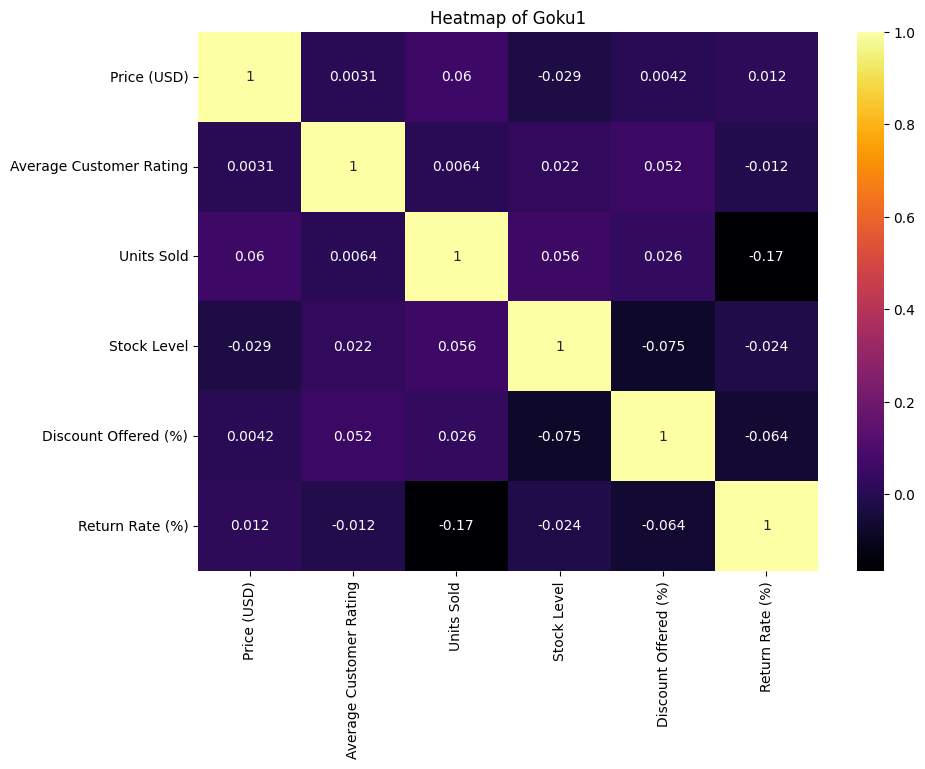

```python
# prompt: give heat map for goku1 with orange and black shades

import matplotlib.pyplot as plt
import seaborn as sns

plt.figure(figsize=(10, 7))
sns.heatmap(goku1.corr(), annot=True, cmap='inferno') # Use inferno or other suitable colormap
plt.title('Heatmap of Goku1')
plt.show()
```

```python
from sklearn.cluster import AgglomerativeClustering


h_clusters = AgglomerativeClustering( n_clusters = 4 )
h_clusters.fit( goku1 )
goku1["h_clusterid"] = h_clusters.labels_
```

```python
h_clusters.labels_
```

```
array([2, 2, 3, 0, 3, 1, 2, 2, 1, 1, 1, 1, 1, 0, 1, 3, 0, 2, 1, 1, 2, 1,
       2, 1, 2, 0, 0, 0, 2, 1, 0, 2, 0, 2, 0, 0, 1, 0, 0, 1, 1, 0, 2, 2,
       1, 1, 1, 2, 0, 0, 0, 3, 2, 0, 1, 0, 1, 0, 2, 2, 3, 2, 1, 2, 3, 1,
       3, 1, 1, 3, 1, 3, 1, 2, 1, 1, 2, 1, 2, 0, 2, 3, 2, 1, 1, 1, 2, 0,
       0, 3, 2, 2, 1, 1, 2, 0, 2, 0, 2, 3, 2, 0, 3, 0, 3, 1, 0, 1, 2, 3,
       0, 2, 2, 0, 2, 3, 2, 2, 1, 1, 0, 2, 3, 1, 3, 3, 1, 2, 3, 0, 2, 1,
       3, 2, 3, 1, 0, 2, 1, 2, 1, 3, 1, 0, 0, 3, 1, 3, 1, 0, 2, 0, 1, 0,
       0, 0, 0, 1, 3, 1, 2, 0, 2, 3, 2, 1, 2, 3, 2, 2, 3, 2, 3, 0, 0, 0,
       0, 1, 0, 1, 2, 1, 1, 1, 2, 0, 1, 0, 0, 2, 0, 3, 3, 3, 2, 1, 2, 0,
       2, 0, 2, 2, 0, 0, 1, 1, 1, 1, 2, 3, 1, 3, 2, 2, 2, 0, 3, 2, 0, 1,
       2, 1, 1, 0, 0, 2, 1, 3, 1, 1, 2, 2, 2, 2, 2, 0, 0, 0, 1, 0, 0, 3,
       1, 1, 2, 1, 2, 2, 2, 0, 3, 1, 0, 0, 0, 3, 2, 0, 3, 3, 3, 3, 3, 0,
       0, 2, 0, 2, 3, 1, 0, 0, 0, 0, 1, 2, 2, 2, 1, 1, 0, 2, 2, 1, 2, 0,
       2, 1, 2, 2, 2, 2, 3, 3, 1, 3, 2, 1, 0, 2, 0, 2, 0, 2, 0, 2, 3, 2,
       2, 1, 2, 1, 1, 3, 0, 2, 2, 1, 1, 2, 0, 0, 0, 2, 2, 0, 0, 2, 2, 1,
       0, 0, 2, 3, 1, 2, 0, 1, 0, 0, 3, 0, 1, 1, 3, 2, 3])
```

```python
goku1[goku1.h_clusterid == 0] # Change goku to goku1
```

|  | Price (USD) | Average Customer Rating | Units Sold | Stock Level | Discount Offered (%) | Return Rate (%) | h_clusterid |
| --- | --- | --- | --- | --- | --- | --- | --- |
| 3 | -0.678044 | -0.390305 | 1.141210 | 0.384186 | -0.131952 | 1.225984 | 0 |
| 13 | -0.294100 | 0.198546 | -1.862582 | -0.770489 | 0.031825 | 1.530368 | 0 |
| 16 | -0.104360 | 1.039762 | 1.284248 | 0.034284 | 1.226115 | 0.343448 | 0 |
| 25 | -0.572135 | -0.306183 | -1.004356 | -1.540272 | 1.187024 | 1.699671 | 0 |
| 26 | 0.275562 | -0.726791 | -1.504988 | 0.069274 | -0.210808 | 0.990040 | 0 |
| ... | ... | ... | ... | ... | ... | ... | ... |
| 331 | -1.535294 | -1.231520 | -0.789799 | 0.279215 | 0.555506 | 0.548773 | 0 |
| 336 | -1.137644 | -0.390305 | -0.289167 | -1.365322 | -1.649752 | 0.343448 | 0 |
| 338 | 1.404971 | 1.544491 | 0.139946 | -0.630529 | -0.487813 | 0.952217 | 0 |
| 339 | 1.404971 | -0.390305 | -2.220177 | -1.610253 | 1.430331 | 1.233188 | 0 |
| 341 | -1.148511 | -0.979156 | 0.426022 | 0.244225 | 0.446996 | 0.894583 | 0 |

93 rows × 7 columns

```python
goku1[goku1.h_clusterid == 1]
```

|  | Price (USD) | Average Customer Rating | Units Sold | Stock Level | Discount Offered (%) | Return Rate (%) | h_clusterid |
| --- | --- | --- | --- | --- | --- | --- | --- |
| 5 | 0.289301 | -1.063277 | 0.354503 | -0.105676 | -0.061858 | 0.424497 | 1 |
| 8 | -0.864829 | -1.652128 | -0.217648 | -0.070686 | -0.425807 | -1.164066 | 1 |
| 9 | -0.360465 | -1.483885 | -0.003092 | -0.490568 | -0.727749 | -1.765631 | 1 |
| 10 | 0.430436 | -1.063277 | 0.211465 | 2.098703 | -1.006103 | -0.431022 | 1 |
| 11 | 1.404971 | -1.652128 | 0.926654 | 1.853772 | 0.876320 | -1.147857 | 1 |
| ... | ... | ... | ... | ... | ... | ... | ... |
| 329 | 1.404971 | -0.810912 | -0.646761 | -0.245637 | -0.857153 | 0.730683 | 1 |
| 334 | -1.294176 | -0.306183 | -0.074610 | 1.153969 | 0.909345 | -1.266729 | 1 |
| 337 | 1.404971 | -0.810912 | 1.498805 | -0.035696 | -1.660536 | -0.277929 | 1 |
| 342 | -0.694787 | -0.979156 | 0.211465 | 1.853772 | -0.942749 | -0.731804 | 1 |
| 343 | 0.784719 | -1.652128 | -0.432205 | -0.385597 | -0.607107 | -0.342768 | 1 |

92 rows × 7 columns

```python
goku1[goku1.h_clusterid == 2]
```

|  | Price (USD) | Average Customer Rating | Units Sold | Stock Level | Discount Offered (%) | Return Rate (%) | h_clusterid |
| --- | --- | --- | --- | --- | --- | --- | --- |
| 0 | -0.945541 | 0.703276 | -0.074610 | -0.420588 | 1.264532 | -1.581920 | 2 |
| 1 | 0.309574 | 1.123884 | -1.075875 | -0.315617 | 1.490315 | -0.710191 | 2 |
| 6 | -1.312824 | -0.726791 | -0.074610 | -0.875460 | 1.219375 | -0.946134 | 2 |
| 7 | -1.294160 | 1.292127 | -1.361950 | -1.330331 | 0.293328 | -1.250519 | 2 |
| 17 | -0.449089 | -0.558548 | -1.504988 | -0.700509 | 1.614327 | -0.947935 | 2 |
| ... | ... | ... | ... | ... | ... | ... | ... |
| 327 | 1.404971 | 0.535033 | 0.426022 | -0.210647 | -0.083426 | -1.785443 | 2 |
| 328 | -1.662099 | 0.450911 | -1.934101 | -1.190371 | 0.730067 | -1.092023 | 2 |
| 332 | -0.509529 | -0.306183 | 0.783616 | 0.909038 | -1.142920 | -0.587717 | 2 |
| 335 | -0.911824 | 0.450911 | -1.290431 | -0.490568 | -0.009962 | -0.908311 | 2 |
| 345 | 1.306334 | -0.474426 | -0.789799 | -0.700509 | 0.765114 | -0.447232 | 2 |

107 rows × 7 columns

```python
goku1[goku1.h_clusterid == 3]
```

|  | Price (USD) | Average Customer Rating | Units Sold | Stock Level | Discount Offered (%) | Return Rate (%) | h_clusterid |
| --- | --- | --- | --- | --- | --- | --- | --- |
| 2 | 0.311823 | 1.039762 | 0.855135 | 0.139255 | -1.189425 | 1.532169 | 3 |
| 4 | -0.643064 | 0.535033 | 0.354503 | 1.888762 | 1.615001 | 1.699671 | 3 |
| 15 | -1.070803 | 1.292127 | -0.646761 | 1.433890 | 0.254238 | 1.325044 | 3 |
| 51 | 0.790136 | 0.114425 | -0.217648 | 1.014008 | -0.698094 | 0.433503 | 3 |
| 60 | -1.375266 | 0.282668 | 0.068427 | 0.769077 | 0.891148 | 0.669446 | 3 |
| 64 | -0.622184 | -0.306183 | -0.503724 | 0.209235 | -0.047705 | 0.473127 | 3 |
| 66 | -1.111758 | 0.030303 | -1.862582 | 0.244225 | -0.317296 | -0.492259 | 3 |
| 69 | 0.838642 | 0.787397 | -0.789799 | 0.244225 | -0.515446 | 0.582993 | 3 |
| 71 | -1.145917 | 0.282668 | -1.147394 | 1.188959 | 1.032683 | 0.057074 | 3 |
| 81 | 1.404971 | 1.376248 | -0.003092 | 0.279215 | -1.521696 | 0.945013 | 3 |
| 89 | -1.437199 | 0.282668 | -0.146129 | -0.105676 | -0.325384 | 1.546578 | 3 |
| 99 | -0.156133 | 1.039762 | 0.926654 | 0.769077 | -1.276368 | 1.368270 | 3 |
| 102 | -1.533653 | -0.810912 | 0.497541 | 1.293930 | -0.176435 | 1.265608 | 3 |
| 104 | -1.244012 | -0.558548 | -0.217648 | 1.258939 | 0.414645 | 0.008445 | 3 |
| 109 | -1.106587 | -0.222062 | -0.360686 | 1.223949 | 1.081210 | 0.577590 | 3 |
| 115 | -0.923397 | 0.450911 | -0.503724 | 1.433890 | -0.776276 | 1.445717 | 3 |
| 122 | -0.849546 | 1.460370 | -1.504988 | 0.699097 | -0.620587 | -0.306746 | 3 |
| 124 | -0.232593 | 0.619154 | -0.575243 | 0.874048 | 0.031825 | 0.312830 | 3 |
| 125 | -0.369575 | 1.376248 | 0.139946 | 0.279215 | -1.533154 | 0.305625 | 3 |
| 128 | -0.700434 | 1.376248 | -1.361950 | 0.139255 | -1.479910 | 1.350259 | 3 |
| 132 | -1.342370 | 1.376248 | -0.074610 | 1.153969 | 0.806226 | 0.997245 | 3 |
| 134 | 1.404971 | 1.460370 | 0.354503 | -0.070686 | -1.347810 | 0.012047 | 3 |
| 141 | -1.039877 | 0.282668 | -0.718280 | 0.174245 | -0.229005 | 1.042272 | 3 |
| 145 | -1.301021 | 0.619154 | -1.147394 | 0.664107 | -1.390271 | 1.260204 | 3 |
| 147 | -1.120244 | 0.703276 | -1.576507 | 0.349196 | -0.026812 | 0.999046 | 3 |
| 158 | -0.984542 | 1.208005 | -0.503724 | 0.909038 | 0.676822 | 0.990040 | 3 |
| 163 | 0.946192 | 0.955640 | 0.426022 | 0.069274 | -1.528436 | -0.146449 | 3 |
| 167 | -0.976187 | -0.390305 | -2.077139 | 0.349196 | -0.232375 | 0.730683 | 3 |
| 170 | 0.356931 | 1.208005 | 0.068427 | 0.664107 | -0.448048 | 1.490744 | 3 |
| 172 | -0.391112 | 0.871519 | -0.432205 | 2.798506 | -1.514283 | 0.022854 | 3 |
| 191 | -1.401546 | -1.399763 | -0.575243 | 1.538861 | 0.712543 | 0.995444 | 3 |
| 192 | -0.170578 | -0.306183 | -0.289167 | 0.629117 | -1.019582 | 0.438906 | 3 |
| 193 | -1.194801 | 1.208005 | 0.569059 | 2.378624 | 1.309014 | -0.492259 | 3 |
| 209 | -0.767669 | -0.558548 | -1.361950 | 0.489156 | 0.098549 | -0.184272 | 3 |
| 211 | -0.288683 | 1.544491 | -2.005620 | 0.384186 | -1.657166 | 0.763103 | 3 |
| 216 | -0.659331 | -0.390305 | -1.004356 | 0.279215 | -0.640132 | 1.271011 | 3 |
| 227 | -1.074381 | 1.208005 | -0.503724 | 0.804068 | -1.631555 | 0.258797 | 3 |
| 241 | -0.586744 | -0.053818 | -1.862582 | 0.524146 | 0.939000 | 0.608209 | 3 |
| 250 | 0.028173 | 1.039762 | -0.360686 | 0.664107 | -0.094209 | 0.671247 | 3 |
| 255 | -0.680982 | 1.208005 | 0.783616 | 2.798506 | 1.650048 | 0.008445 | 3 |
| 258 | -0.616357 | 1.123884 | -0.861318 | 0.734087 | -1.436101 | 0.608209 | 3 |
| 259 | 0.556371 | 1.208005 | -0.217648 | 0.874048 | -0.458832 | 0.946814 | 3 |
| 260 | 1.404971 | 0.619154 | 0.354503 | 1.328920 | -0.931291 | 1.589804 | 3 |
| 261 | -1.017192 | 1.039762 | -0.789799 | 0.489156 | -1.031040 | 0.959422 | 3 |
| 262 | 1.404971 | 0.619154 | -1.004356 | 0.874048 | -1.216384 | 0.365061 | 3 |
| 268 | -1.444192 | 1.208005 | 0.426022 | 1.503870 | 0.452387 | 0.736086 | 3 |
| 292 | -0.291638 | 0.366789 | -0.432205 | 1.328920 | -0.142062 | 0.838749 | 3 |
| 293 | -0.598661 | 1.376248 | -1.576507 | 1.958742 | 0.151119 | 1.216978 | 3 |
| 295 | -1.399002 | 1.376248 | -1.934101 | -0.070686 | -1.543264 | 1.697870 | 3 |
| 306 | -1.669896 | 1.544491 | -0.861318 | 0.209235 | -1.026996 | 0.707269 | 3 |
| 313 | -1.135231 | -0.642669 | -0.432205 | 0.174245 | -0.218222 | 1.157542 | 3 |
| 333 | -0.540651 | 1.460370 | 0.855135 | 2.028723 | 0.213125 | -0.429221 | 3 |
| 340 | 1.328511 | 1.292127 | -0.718280 | 0.244225 | -0.920507 | 0.112908 | 3 |
| 344 | -1.200841 | 0.450911 | -1.218913 | 0.279215 | 1.166805 | 0.730683 | 3 |
| 346 | -0.392753 | 1.208005 | 0.139946 | 0.909038 | -1.369377 | 0.282211 | 3 |

```python
# prompt: find the shapes of h_clusterid == 1, h_clusterid == 2,h_clusterid == 0, h_clusterid == 3

print(goku1[goku1.h_clusterid == 0].shape)
print(goku1[goku1.h_clusterid == 1].shape)
print(goku1[goku1.h_clusterid == 2].shape)
print(goku1[goku1.h_clusterid == 3].shape)
```

```
(93, 7)
(92, 7)
(107, 7)
(55, 7)
```

```python
goku1.groupby('h_clusterid')[['Price (USD)', 'Average Customer Rating', 'Units Sold', 'Stock Level', 'Discount Offered (%)', 'Return Rate (%)']].mean()
```

| h_clusterid | Price (USD) | Average Customer Rating | Units Sold | Stock Level | Discount Offered (%) | Return Rate (%) |
| --- | --- | --- | --- | --- | --- | --- |
| 0 | 0.139453 | -0.153317 | -0.081532 | -0.527063 | 0.413702 | 0.880193 |
| 1 | 0.094436 | -1.072421 | 0.140724 | 0.298612 | -0.362819 | -0.439283 |
| 2 | 0.059577 | 0.714282 | 0.207455 | -0.225689 | 0.130282 | -0.745809 |
| 3 | -0.509672 | 0.663509 | -0.501123 | 0.830787 | -0.346094 | 0.697412 |

# Q1

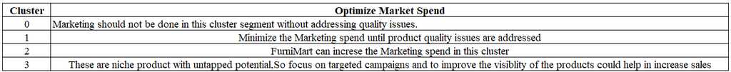

**Relevant Data for Analysis**:

- Price, Customer Ratings, Units Sold, Stock Level, and Return Rate.
- Marketing spend data (e.g., ad impressions, costs) to analyze ROI by cluster.

# Q2

**Identifying High-Return Segments**:

- Cluster 0 has the highest return rate (0.8802). This suggests a potential issue with product quality or mismatched customer expectations.
- Cluster 3 also has a notable return rate (0.6974).

**Steps to Address Return Rates**:

- Conduct Quality Audits: Investigate products in Cluster 0 for defects, misleading descriptions, or other quality issues.
- Customer Feedback: Analyze reviews to identify specific pain points causing returns.
- Targeted Quality Improvements: Enhance product features and align them better with customer expectations.
- Refine Marketing Campaigns: Ensure ads accurately represent product attributes to avoid overpromising.
- Returns Policy Adjustments: Implement stricter policies or incentives for fewer returns in these clusters.

**How Clustering Helps**: Clustering helps pinpoint which segments (like Cluster 0) have higher return rates, enabling FurniMart to prioritize improvements efficiently.

# Q3

**Insights from Clusters**:

- Cluster 0: Low stock levels and moderate sales suggest understocking. This cluster needs better forecasting to prevent lost sales opportunities.
- Cluster 1: High stock levels with good units sold indicate possible overstocking. Aligning stock with demand is crucial to reduce holding costs.
- Cluster 2: Low stock levels and high sales volume indicate popular products with potential stockouts. These products require better replenishment strategies.
- Cluster 3: High stock levels with low units sold suggest overstocking of niche products.

**How Clustering Helps in align stock levels with demand**:

Clustering highlights stock-demand mismatches, enabling FurniMart to focus on **demand forecasting** and better align inventory with sales trends.

# Q4

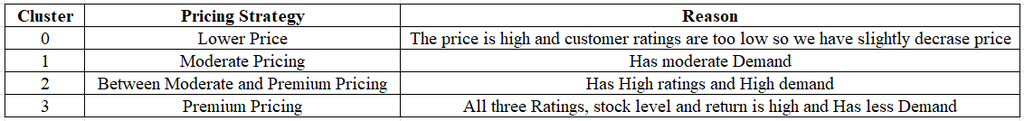

# Q5

**To stay competitive, FurniMart should incorporate the following additional data points**:

- Customer Demographics: Age, gender, location, and income levels to personalize segmentation further.
- Competitor Data: Competitor pricing, product features, and promotional strategies to benchmark performance.
- Seasonality: Data on sales fluctuations during holidays or seasonal peaks to better predict demand.
- Customer Acquisition Costs (CAC) and Lifetime Value (CLV): To measure the true profitability of each product segment.
- Product Reviews Sentiment Analysis: Text analysis of customer reviews to identify recurring quality or design issues.
- Marketing Engagement: Click-through rates, impressions, and ROI from campaigns to fine-tune ad spend by cluster.
- Emerging Trends: Data on new furniture trends, such as eco-friendly materials or modular furniture, to inform product development.

**Impact on Segmentation Strategy**:

- Changes in consumer preferences or emerging product categories may create new clusters or shift existing ones.
- Adding demographic and sentiment analysis will refine segmentation, enabling FurniMart to target the right customers with the right products.